```python
# Automatically reload imported modules that are changed outside this notebook
%load_ext autoreload
%autoreload 2

# More pixels in figures
import matplotlib.pyplot as plt
%matplotlib inline
plt.rcParams["figure.dpi"] = 200

# Init PRNG with fixed seed for reproducibility
import numpy as np
np_rng = np.random.default_rng(1)

import tensorflow as tf
tf.random.set_seed(np_rng.integers(0, tf.int64.max))
```

# Language vectors, recurrent neural networks, and an angular proximity loss function

**2020-11-21**

In this example, we take a different approach for training language vectors (embeddings) compared to `common-voice-embeddings`. Previously, we trained a neural network on a classification task and used one of its layers as the representation for different classes. In this example, we train a neural network directly on the language vector task by maximizing the angular distance between vectors of different classes. We'll be using the approach described by [G. Gelly and J.L. Gauvain](https://www.isca-speech.org/archive/Interspeech_2017/abstracts/1334.html).

## Data

We will continue with the same, 4-language Common Voice data as in all previous examples.

```python
import urllib.parse
from IPython.display import display, Markdown


languages = """
    et
    mn
    ta
    tr
""".split()

languages = sorted(l.strip() for l in languages)

display(Markdown("### Languages"))
display(Markdown('\n'.join("* `{}`".format(l) for l in languages)))

bcp47_validator_url = 'https://schneegans.de/lv/?tags='
display(Markdown("See [this tool]({}) for a description of the BCP-47 language codes."
                 .format(bcp47_validator_url + urllib.parse.quote('\n'.join(languages)))))
```

Languages

- `et`

- `mn`

- `ta`

- `tr`

See [this tool](https://schneegans.de/lv/?tags=et%0Amn%0Ata%0Atr) for a description of the BCP-47 language codes.

## Loading and preparing the metadata

```python
import os

from lidbox.meta import (
    common_voice,
    generate_label2target,
    verify_integrity,
    read_audio_durations,
    random_oversampling_on_split
)


workdir = "/data/exp/cv4-angular-lstm"
datadir = "/mnt/data/speech/common-voice/downloads/2020/cv-corpus"

print("work dir:", workdir)
print("data source dir:", datadir)
print()

os.makedirs(workdir, exist_ok=True)
assert os.path.isdir(datadir), datadir + " does not exist"

dirs = sorted((f for f in os.scandir(datadir) if f.is_dir()), key=lambda f: f.name)

print(datadir)
for d in dirs:
    if d.name in languages:
        print(' ', d.name)
        for f in os.scandir(d):
            print('   ', f.name)

missing_languages = set(languages) - set(d.name for d in dirs)
assert missing_languages == set(), "missing languages: {}".format(missing_languages)

meta = common_voice.load_all(datadir, languages)
meta, lang2target = generate_label2target(meta)

print("\nsize of all metadata", meta.shape)
meta = meta.dropna()
print("after dropping NaN rows", meta.shape)

print("verifying integrity")
verify_integrity(meta)
print("ok\n")

print("reading audio durations")
meta["duration"] = read_audio_durations(meta)
print("balancing the label distributions")
meta = random_oversampling_on_split(meta, "train")
```

```
work dir: /data/exp/cv4-angular-lstm
data source dir: /mnt/data/speech/common-voice/downloads/2020/cv-corpus

/mnt/data/speech/common-voice/downloads/2020/cv-corpus
  et
    validated.tsv
    invalidated.tsv
    other.tsv
    dev.tsv
    train.tsv
    clips
    test.tsv
    reported.tsv
  mn
    validated.tsv
    invalidated.tsv
    other.tsv
    dev.tsv
    train.tsv
    clips
    test.tsv
    reported.tsv
  ta
    validated.tsv
    invalidated.tsv
    other.tsv
    dev.tsv
    train.tsv
    clips
    test.tsv
    reported.tsv
  tr
    validated.tsv
    invalidated.tsv
    other.tsv
    dev.tsv
    train.tsv
    clips
    test.tsv
    reported.tsv

size of all metadata (23842, 6)
after dropping NaN rows (23842, 6)
verifying integrity
ok

reading audio durations
balancing the label distributions
```

## Preparing the feature extraction pipeline

Most of the preprocessing will be as in `common-voice-embeddings`, but this time we will not be training on samples with varying length.

We will make these changes:

- Signals will be divided into 3.2 second chunks, with 75% overlap, as suggested in the [paper](https://www.isca-speech.org/archive/Interspeech_2017/abstracts/1334.html).
- Every signal that is shorter than 3.2 seconds will be repeatedly appended to itself until it is at least 3.2 seconds long.
- Random speed changes are applied only once, before caching the training set signals to disk. This is because `tf.keras.Model.fit` assumes the training set length does not change. This could probably be fixed by writing a custom training loop but we won't be doing that here.

```python
import scipy.signal

from lidbox.features import audio, cmvn
import lidbox.data.steps as ds_steps


TF_AUTOTUNE = tf.data.experimental.AUTOTUNE


def metadata_to_dataset_input(meta):
    return {
        "id": tf.constant(meta.index, tf.string),
        "path": tf.constant(meta.path, tf.string),
        "label": tf.constant(meta.label, tf.string),
        "target": tf.constant(meta.target, tf.int32),
        "split": tf.constant(meta.split, tf.string),
        "is_copy": tf.constant(meta.is_copy, tf.bool),
    }


def read_mp3(x):
    s, r = audio.read_mp3(x["path"])
    out_rate = 16000
    s = audio.resample(s, r, out_rate)
    s = audio.peak_normalize(s, dBFS=-3.0)
    s = audio.remove_silence(s, out_rate)
    return dict(x, signal=s, sample_rate=out_rate)


def random_filter(x):
    def scipy_filter(s, N=10):
        b = np_rng.normal(0, 1, N)
        return scipy.signal.lfilter(b, 1.0, s).astype(np.float32), b
    s, _ = tf.numpy_function(
        scipy_filter,
        [x["signal"]],
        [tf.float32, tf.float64],
        name="np_random_filter")
    s = tf.cast(s, tf.float32)
    s = audio.peak_normalize(s, dBFS=-3.0)
    return dict(x, signal=s)


def random_speed_change(ds):
    return ds_steps.random_signal_speed_change(ds, min=0.9, max=1.1, flag="is_copy")


def create_signal_chunks(ds):
    ds = ds_steps.repeat_too_short_signals(ds, 3200)
    ds = ds_steps.create_signal_chunks(ds, 3200, 800)
    return ds


def batch_extract_features(x):
    with tf.device("GPU"):
        signals, rates = x["signal"], x["sample_rate"]
        S = audio.spectrograms(signals, rates[0])
        S = audio.linear_to_mel(S, rates[0])
        S = tf.math.log(S + 1e-6)
        S = cmvn(S, normalize_variance=False)
    return dict(x, logmelspec=S)


def pipeline_from_meta(data, split):
    if split == "train":
        data = data.sample(frac=1, random_state=np_rng.bit_generator)

    ds = (tf.data.Dataset
            .from_tensor_slices(metadata_to_dataset_input(data))
            .map(read_mp3, num_parallel_calls=TF_AUTOTUNE))

    if split == "train":
        return (ds
            .apply(random_speed_change)
            .cache(os.path.join(cachedir, "data", split))
            .prefetch(100)
            .map(random_filter, num_parallel_calls=TF_AUTOTUNE)
            .apply(create_signal_chunks)
            .batch(100)
            .map(batch_extract_features, num_parallel_calls=TF_AUTOTUNE)
            .unbatch())
    else:
        return (ds
            .apply(create_signal_chunks)
            .batch(100)
            .map(batch_extract_features, num_parallel_calls=TF_AUTOTUNE)
            .unbatch()
            .cache(os.path.join(cachedir, "data", split))
            .prefetch(100))


cachedir = os.path.join(workdir, "cache")
os.makedirs(os.path.join(cachedir, "data"))

split2ds = {split: pipeline_from_meta(meta[meta["split"]==split], split)
            for split in meta.split.unique()}
```

```
2020-11-21 23:05:37.173 I lidbox.data.steps: Repeating all signals until they are at least 3200 ms
2020-11-21 23:05:37.214 I lidbox.data.steps: Dividing every signal in the dataset into new signals by creating signal chunks of length 3200 ms and offset 800 ms. Maximum amount of padding allowed in the last chunk is 0 ms.
2020-11-21 23:05:37.883 I lidbox.data.steps: Applying random resampling to signals with a random speed ratio chosen uniformly at random from [0.900, 1.100]
2020-11-21 23:05:37.993 I lidbox.data.steps: Repeating all signals until they are at least 3200 ms
2020-11-21 23:05:38.000 I lidbox.data.steps: Dividing every signal in the dataset into new signals by creating signal chunks of length 3200 ms and offset 800 ms. Maximum amount of padding allowed in the last chunk is 0 ms.
2020-11-21 23:05:38.165 I lidbox.data.steps: Repeating all signals until they are at least 3200 ms
2020-11-21 23:05:38.175 I lidbox.data.steps: Dividing every signal in the dataset into new signals by creating signal chunks of length 3200 ms and offset 800 ms. Maximum amount of padding allowed in the last chunk is 0 ms.
```

### Filling the caches

```python
for split, ds in split2ds.items():
    print("filling", split, "cache")
    _ = ds_steps.consume(ds, log_interval=5000)
```

```
filling test cache
2020-11-21 23:05:38.335 I lidbox.data.steps: Exhausting the dataset iterator by iterating over all elements, log_interval = 5000
2020-11-21 23:05:48.470 I lidbox.data.steps: 5000 done, 493.371 elements per second.
2020-11-21 23:05:57.115 I lidbox.data.steps: 10000 done, 578.409 elements per second.
2020-11-21 23:06:05.999 I lidbox.data.steps: 15000 done, 562.872 elements per second.
2020-11-21 23:06:17.073 I lidbox.data.steps: 20000 done, 451.544 elements per second.
2020-11-21 23:06:19.066 I lidbox.data.steps: 21857 done, 932.154 elements per second.
filling train cache
2020-11-21 23:06:19.070 I lidbox.data.steps: Exhausting the dataset iterator by iterating over all elements, log_interval = 5000
2020-11-21 23:06:31.611 I lidbox.data.steps: 5000 done, 398.694 elements per second.
2020-11-21 23:06:42.470 I lidbox.data.steps: 10000 done, 460.478 elements per second.
2020-11-21 23:06:53.318 I lidbox.data.steps: 15000 done, 460.963 elements per second.
2020-11-21 23:07:03.804 I lidbox.data.steps: 20000 done, 476.864 elements per second.
2020-11-21 23:07:14.153 I lidbox.data.steps: 25000 done, 483.173 elements per second.
2020-11-21 23:07:24.768 I lidbox.data.steps: 30000 done, 471.060 elements per second.
2020-11-21 23:07:35.201 I lidbox.data.steps: 35000 done, 479.282 elements per second.
2020-11-21 23:07:45.518 I lidbox.data.steps: 40000 done, 484.693 elements per second.
2020-11-21 23:07:52.277 I lidbox.data.steps: 43762 done, 556.673 elements per second.
filling dev cache
2020-11-21 23:07:52.280 I lidbox.data.steps: Exhausting the dataset iterator by iterating over all elements, log_interval = 5000
2020-11-21 23:08:02.294 I lidbox.data.steps: 5000 done, 499.328 elements per second.
2020-11-21 23:08:10.649 I lidbox.data.steps: 10000 done, 598.444 elements per second.
2020-11-21 23:08:22.067 I lidbox.data.steps: 15000 done, 437.951 elements per second.
2020-11-21 23:08:27.765 I lidbox.data.steps: 20000 done, 877.561 elements per second.
2020-11-21 23:08:31.175 I lidbox.data.steps: 21967 done, 577.076 elements per second.
```

## Training the LSTM model with angular proximity loss

`lidbox` implements both the model and the angular proximity loss function used in the reference paper. The loss function aims to maximize the cosine distance of language vectors of different languages and minimize the distance for vectors of the same language. Reference vectors will be generated for each class such that all reference vectors are orthogonal to each other.

In addition, we'll add [random channel dropout](https://dl.acm.org/doi/abs/10.1016/j.patrec.2017.09.023) to avoid overfitting on noise, as in the `common-voice-small` example.

```python
from lidbox.models import ap_lstm
from lidbox.losses import SparseAngularProximity


def create_model(num_freq_bins=40, num_labels=len(lang2target)):
    m = ap_lstm.create(
        input_shape=[None, num_freq_bins],
        num_outputs=num_labels,
        num_lstm_units=200,
        channel_dropout_rate=0.8)
    m.compile(
        loss=SparseAngularProximity(num_labels, m.output.shape[1]),
        optimizer=tf.keras.optimizers.Adam(learning_rate=1e-3))
    return m


model = create_model()
model.summary()
```

```
Model: "angular_proximity_lstm"
__________________________________________________________________________________________________
Layer (type)                    Output Shape         Param #     Connected to
==================================================================================================
input (InputLayer)              [(None, None, 40)]   0
__________________________________________________________________________________________________
channel_dropout (SpatialDropout (None, None, 40)     0           input[0][0]
__________________________________________________________________________________________________
blstm_1 (Bidirectional)         (None, None, 400)    385600      channel_dropout[0][0]
__________________________________________________________________________________________________
blstm_2 (Bidirectional)         (None, None, 400)    961600      blstm_1[0][0]
__________________________________________________________________________________________________
tf_op_layer_Mul (TensorFlowOpLa [(None, None, 400)]  0           blstm_1[0][0]
__________________________________________________________________________________________________
tf_op_layer_Mul_1 (TensorFlowOp [(None, None, 400)]  0           blstm_2[0][0]
__________________________________________________________________________________________________
blstm_concat (Concatenate)      (None, None, 800)    0           tf_op_layer_Mul[0][0]
                                                                 tf_op_layer_Mul_1[0][0]
__________________________________________________________________________________________________
avg_over_time (GlobalAveragePoo (None, 800)          0           blstm_concat[0][0]
__________________________________________________________________________________________________
tf_op_layer_Square (TensorFlowO [(None, 800)]        0           avg_over_time[0][0]
__________________________________________________________________________________________________
tf_op_layer_Sum (TensorFlowOpLa [(None, 1)]          0           tf_op_layer_Square[0][0]
__________________________________________________________________________________________________
tf_op_layer_Maximum (TensorFlow [(None, 1)]          0           tf_op_layer_Sum[0][0]
__________________________________________________________________________________________________
tf_op_layer_Rsqrt (TensorFlowOp [(None, 1)]          0           tf_op_layer_Maximum[0][0]
__________________________________________________________________________________________________
tf_op_layer_Mul_2 (TensorFlowOp [(None, 800)]        0           avg_over_time[0][0]
                                                                 tf_op_layer_Rsqrt[0][0]
==================================================================================================
Total params: 1,347,200
Trainable params: 1,347,200
Non-trainable params: 0
__________________________________________________________________________________________________
```

```python
callbacks = [
    tf.keras.callbacks.TensorBoard(
        log_dir=os.path.join(cachedir, "tensorboard", model.name),
        update_freq="epoch",
        write_images=True,
        profile_batch=0,
    ),
    tf.keras.callbacks.EarlyStopping(
        monitor='val_loss',
        patience=10,
    ),
    tf.keras.callbacks.ModelCheckpoint(
        os.path.join(cachedir, "model", model.name),
        monitor='val_loss',
        save_weights_only=True,
        save_best_only=True,
        verbose=1,
    ),
]


def as_model_input(x):
    return x["logmelspec"], x["target"]


train_ds = split2ds["train"].map(as_model_input).shuffle(5000)
dev_ds = split2ds["dev"].map(as_model_input)

history = model.fit(
    train_ds.batch(32),
    validation_data=dev_ds.batch(32),
    callbacks=callbacks,
    verbose=2,
    epochs=100)
```

```
Epoch 00001: val_loss improved from inf to 9.98566, saving model to /data/exp/cv4-angular-lstm/cache/model/angular_proximity_lstm
1368/1368 - 104s - loss: 11.0557 - val_loss: 9.9857

Epoch 00002: val_loss improved from 9.98566 to 9.37180, saving model to /data/exp/cv4-angular-lstm/cache/model/angular_proximity_lstm
1368/1368 - 103s - loss: 10.2950 - val_loss: 9.3718

Epoch 00003: val_loss improved from 9.37180 to 9.22063, saving model to /data/exp/cv4-angular-lstm/cache/model/angular_proximity_lstm
1368/1368 - 104s - loss: 9.9719 - val_loss: 9.2206

Epoch 00004: val_loss improved from 9.22063 to 8.88304, saving model to /data/exp/cv4-angular-lstm/cache/model/angular_proximity_lstm
1368/1368 - 106s - loss: 9.8204 - val_loss: 8.8830

Epoch 00005: val_loss improved from 8.88304 to 8.77573, saving model to /data/exp/cv4-angular-lstm/cache/model/angular_proximity_lstm
1368/1368 - 105s - loss: 9.6827 - val_loss: 8.7757

Epoch 00006: val_loss improved from 8.77573 to 8.60583, saving model to /data/exp/cv4-angular-lstm/cache/model/angular_proximity_lstm
1368/1368 - 104s - loss: 9.5355 - val_loss: 8.6058

Epoch 00007: val_loss improved from 8.60583 to 8.59336, saving model to /data/exp/cv4-angular-lstm/cache/model/angular_proximity_lstm
1368/1368 - 105s - loss: 9.4165 - val_loss: 8.5934

Epoch 00008: val_loss improved from 8.59336 to 8.54300, saving model to /data/exp/cv4-angular-lstm/cache/model/angular_proximity_lstm
1368/1368 - 105s - loss: 9.3556 - val_loss: 8.5430

Epoch 00009: val_loss improved from 8.54300 to 8.50729, saving model to /data/exp/cv4-angular-lstm/cache/model/angular_proximity_lstm
1368/1368 - 105s - loss: 9.2963 - val_loss: 8.5073

Epoch 00010: val_loss improved from 8.50729 to 8.35023, saving model to /data/exp/cv4-angular-lstm/cache/model/angular_proximity_lstm
1368/1368 - 104s - loss: 9.2043 - val_loss: 8.3502

Epoch 00011: val_loss improved from 8.35023 to 8.27633, saving model to /data/exp/cv4-angular-lstm/cache/model/angular_proximity_lstm
1368/1368 - 104s - loss: 9.1600 - val_loss: 8.2763

Epoch 00012: val_loss did not improve from 8.27633
1368/1368 - 105s - loss: 9.1104 - val_loss: 8.2821

Epoch 00013: val_loss did not improve from 8.27633
1368/1368 - 104s - loss: 9.0874 - val_loss: 8.3520

Epoch 00014: val_loss improved from 8.27633 to 8.26146, saving model to /data/exp/cv4-angular-lstm/cache/model/angular_proximity_lstm
```

[output cut: 52 more lines]

```

Epoch 00032: val_loss did not improve from 7.78633
1368/1368 - 105s - loss: 8.7093 - val_loss: 7.8477

Epoch 00033: val_loss did not improve from 7.78633
1368/1368 - 105s - loss: 8.7404 - val_loss: 7.8556

Epoch 00034: val_loss did not improve from 7.78633
1368/1368 - 105s - loss: 8.7481 - val_loss: 7.8946

Epoch 00035: val_loss did not improve from 7.78633
1368/1368 - 104s - loss: 8.7423 - val_loss: 7.9347

Epoch 00036: val_loss did not improve from 7.78633
1368/1368 - 105s - loss: 8.7312 - val_loss: 7.7906
```

## Evaluating as an end-to-end classifier

The angular proximity loss function uses reference directions for each language, such that each direction is orthogonal to each other. By selecting the closest reference direction for every predicted language vector, the model can be used as an end-to-end classifier.

```python
import pandas as pd

from lidbox.util import predict_with_model, classification_report
from lidbox.visualize import draw_confusion_matrix


def load_trained_model():
    model = create_model()
    model.load_weights(os.path.join(cachedir, "model", model.name))
    return model


def display_classification_report(report):
    for m in ("avg_detection_cost", "avg_equal_error_rate", "accuracy"):
        print("{}: {:.3f}".format(m, report[m]))

    lang_metrics = pd.DataFrame.from_dict(
        {k: v for k, v in report.items() if k in lang2target})
    lang_metrics["mean"] = lang_metrics.mean(axis=1)
    display(lang_metrics.T)

    fig, ax = draw_confusion_matrix(report["confusion_matrix"], lang2target)


model = load_trained_model()


def predict_with_ap_loss(x):
    with tf.device("GPU"):
        # Generate language vector for input spectra
        language_vector = model(x["input"], training=False)
        # Predict languages by computing distances to reference directions
        return x["id"], model.loss.predict(language_vector)


chunk2pred = predict_with_model(
    model=model,
    ds=split2ds["test"].map(lambda x: dict(x, input=x["logmelspec"])).batch(128),
    predict_fn=predict_with_ap_loss)
```

### Merging chunk predictions

We divided all samples into 3.2 second chunks, so all predictions are still for these chunks. Lets merge all chunk predictions by taking the average over all chunks for each sample.

```python
chunk2pred
```

| id | prediction |
| --- | --- |
| common_voice_et_18031888-000001 | [-1.4813205, -2.2343419, -1.4084598, -0.8021669] |
| common_voice_et_18031888-000002 | [-1.0812643, -2.0329118, -2.169351, -1.1059672] |
| common_voice_et_18031888-000003 | [-0.7330606, -2.128548, -1.874414, -1.7434976] |
| common_voice_et_18031888-000004 | [-0.75235176, -1.972779, -2.058972, -1.808581] |
| common_voice_et_18031889-000001 | [-0.7298598, -2.0762086, -1.5253065, -1.9248742] |
| ... | ... |
| common_voice_tr_22462713-000001 | [-1.9833467, -0.7498288, -1.965956, -1.6560669] |
| common_voice_tr_22474271-000001 | [-1.7910697, -1.7766209, -0.43017593, -1.8017486] |
| common_voice_tr_22474274-000001 | [-2.0003417, -1.4935714, -0.7071863, -1.6069621] |
| common_voice_tr_22477339-000001 | [-1.4122769, -1.6087383, -2.2520356, -0.8622882] |
| common_voice_tr_22498670-000001 | [-1.4916769, -1.8612272, -0.6381675, -2.0136924] |

21857 rows × 1 columns

```python
from lidbox.util import merge_chunk_predictions


utt2pred = merge_chunk_predictions(chunk2pred)
utt2pred
```

| id | prediction |
| --- | --- |
| common_voice_et_18031888 | [-1.0119994, -2.0921452, -1.8777992, -1.3650532] |
| common_voice_et_18031889 | [-1.4600016, -2.0907407, -1.028938, -1.6188763] |
| common_voice_et_18031891 | [-1.5245651, -1.776621, -2.0704782, -0.73580074] |
| common_voice_et_18038135 | [-1.3484797, -1.2462838, -2.1541154, -1.5248653] |
| common_voice_et_18038136 | [-0.8494967, -1.8381963, -2.0412564, -1.3015724] |
| ... | ... |
| common_voice_tr_22462713 | [-1.9833467, -0.7498288, -1.965956, -1.6560669] |
| common_voice_tr_22474271 | [-1.7910697, -1.7766209, -0.43017593, -1.8017486] |
| common_voice_tr_22474274 | [-2.0003417, -1.4935714, -0.7071863, -1.6069621] |
| common_voice_tr_22477339 | [-1.4122769, -1.6087383, -2.2520356, -0.8622882] |
| common_voice_tr_22498670 | [-1.4916769, -1.8612272, -0.6381675, -2.0136924] |

7569 rows × 1 columns

### Evaluate test set predictions

```
avg_detection_cost: 0.191
avg_equal_error_rate: 0.168
accuracy: 0.683
```

|  | precision | recall | f1-score | support | equal_error_rate |
| --- | --- | --- | --- | --- | --- |
| et | 0.848820 | 0.710028 | 0.773246 | 2483.00 | 0.140779 |
| mn | 0.823422 | 0.497238 | 0.620048 | 1810.00 | 0.182150 |
| ta | 0.583302 | 0.938339 | 0.719401 | 1638.00 | 0.104873 |
| tr | 0.549320 | 0.591575 | 0.569665 | 1638.00 | 0.245996 |
| mean | 0.701216 | 0.684295 | 0.670590 | 1892.25 | 0.168449 |

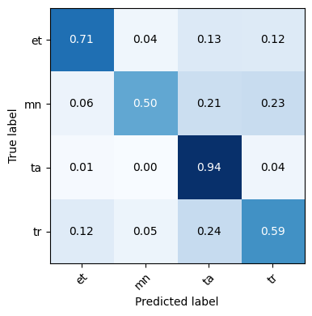

```python
test_meta = meta[meta["split"]=="test"].join(utt2pred, how="outer")
assert not test_meta.isna().any(axis=None), "failed to join predictions"

true_sparse = test_meta.target.to_numpy(np.int32)
pred_dense = np.stack(test_meta.prediction)

report = classification_report(true_sparse, pred_dense, lang2target)
display_classification_report(report)
```

## Extracting all data as language vectors

```python
from lidbox.util import model2function


extractor = model2function(load_trained_model())
print("extractor:", str(extractor))
```

[output not shown]

[output not shown]

[output not shown]

[output not shown]

[output not shown]

[output not shown]

[output not shown]

[output not shown]

[output not shown]

[output not shown]

[output not shown]

[output not shown]

```
extractor: ConcreteFunction <lambda>(x)
  Args:
    x: float32 Tensor, shape=(None, None, 40)
  Returns:
    float32 Tensor, shape=(None, 800)
```

```python
from lidbox.visualize import plot_embedding_vector


def is_not_copy(x):
    return not x["is_copy"]

def batch_extract_embeddings(x):
    with tf.device("GPU"):
        return dict(x, embedding=extractor(x["logmelspec"]))


embedding_demo_ds = (split2ds["train"]
                     .filter(is_not_copy)
                     .take(12)
                     .batch(1)
                     .map(batch_extract_embeddings)
                     .unbatch())

for x in embedding_demo_ds.as_numpy_iterator():
    print(x["id"].decode("utf-8"), x["embedding"].shape)
    plot_embedding_vector(x["embedding"], figsize=(10, 0.2))
```

```
common_voice_tr_18237877-000001 (800,)
```

```
common_voice_tr_18237877-000002 (800,)
```

```
common_voice_tr_18237877-000003 (800,)
```

```
common_voice_tr_19104341-000001 (800,)
```

```
common_voice_tr_19104341-000002 (800,)
```

```
common_voice_tr_19104341-000003 (800,)
```

```
common_voice_mn_18584433-000001 (800,)
```

```
common_voice_mn_18584433-000002 (800,)
```

```
common_voice_mn_18584433-000003 (800,)
```

```
common_voice_ta_20395073-000001 (800,)
```

```
common_voice_ta_20395073-000002 (800,)
```

```
common_voice_ta_20395073-000003 (800,)
```

### Constructing a language vector extractor pipeline

We'll now extend the existing feature extraction pipeline by adding a step where we extract language vectors with the trained model. In addition, we merge all chunks of each sample by summing over all components of its chunk vectors. The vector is then L2-normalized.

```python
from sklearn.preprocessing import normalize
from lidbox.util import predictions_to_dataframe


# Merge chunk vectors by taking the sum over each component and L2-normalizing the result
def sum_and_normalize(pred):
    v = np.stack(pred).sum(axis=0)
    v = normalize(v.reshape((1, -1)), axis=1)
    return np.squeeze(v)


def ds_to_embeddings(ds):
    to_pair = lambda x: (x["id"], x["embedding"])
    ds = (ds
        .batch(128)
        .map(batch_extract_embeddings, num_parallel_calls=TF_AUTOTUNE)
        .unbatch()
        .map(to_pair, num_parallel_calls=TF_AUTOTUNE))

    ids = []
    embeddings = []

    for id, embedding in ds.as_numpy_iterator():
        ids.append(id.decode("utf-8"))
        embeddings.append(embedding.astype(np.float32))

    df = predictions_to_dataframe(ids, embeddings)
    return merge_chunk_predictions(df, merge_rows_fn=sum_and_normalize)


embeddings_by_split = (ds_to_embeddings(ds) for ds in split2ds.values())
m = meta.join(pd.concat(embeddings_by_split, verify_integrity=True), how="outer")
assert not m.prediction.isna().any(axis=None), "Missing embeddings, some rows contained NaN values"

meta = m.rename(columns={"prediction": "embedding"})
```

### Preprocessing the language vectors for back-end training

Now, let's extract all embeddings and integer targets into NumPy-data and preprocess them with scikit-learn.

```
training vectors (16728, 800) (16728,)
test vectors (7569, 800) (7569,)
PLDA reduced dimensions from (16728, 800) to (16728, 3)
```

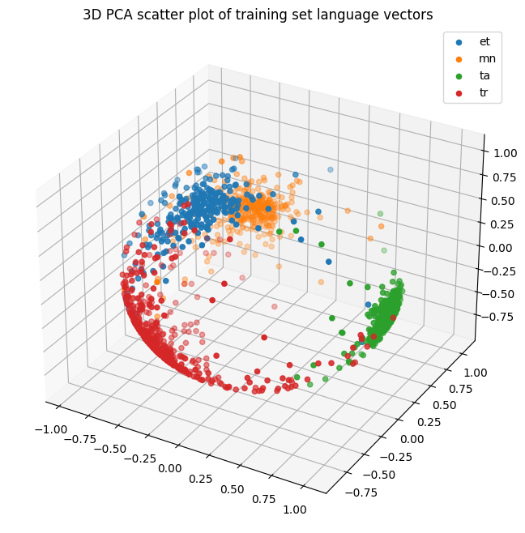

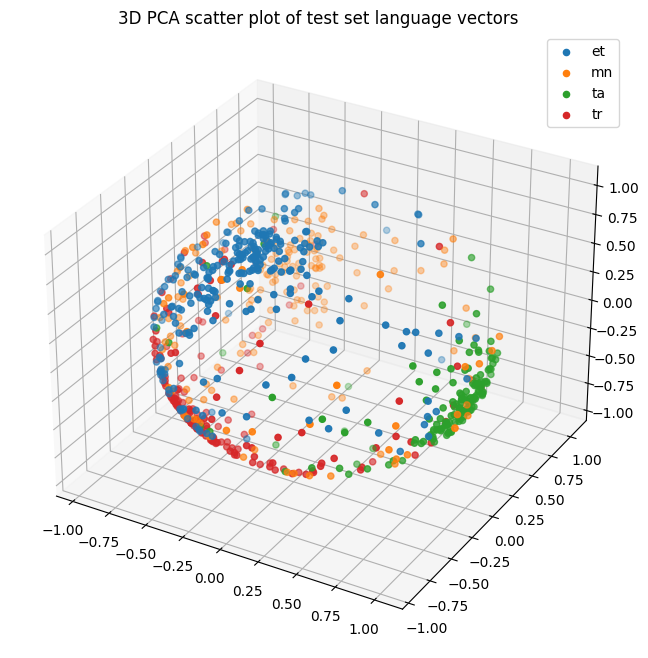

```python
import matplotlib.pyplot as plt
from mpl_toolkits.mplot3d import Axes3D

from sklearn.preprocessing import StandardScaler
from sklearn.decomposition import PCA
from lidbox.embed.sklearn_utils import PLDA


def embeddings_as_numpy_data(df):
    X = np.stack(df.embedding.values).astype(np.float32)
    y = df.target.to_numpy(dtype=np.int32)
    return X, y


def random_sample(X, y, sample_size_ratio):
    N = X.shape[0]
    sample_size = int(sample_size_ratio*N)
    sample_idx = np_rng.choice(np.arange(N), size=sample_size, replace=False)
    return X[sample_idx], y[sample_idx]


def pca_3d_scatterplot_by_label(data, targets, split_name):
    target2lang = {t: l for l, t in lang2target.items()}

    df = pd.DataFrame.from_dict({
        "x": data[:,0],
        "y": data[:,1],
        "z": data[:,2],
        "lang": [target2lang[t] for t in targets],
    })

    fig = plt.figure(figsize=(8, 8))
    ax = fig.add_subplot(111, projection='3d')

    for lang, g in df.groupby("lang"):
        ax.scatter(g.x, g.y, g.z, label=lang)

    ax.legend()
    ax.set_title("3D PCA scatter plot of {} set language vectors".format(split_name))
    plt.show()


train_X, train_y = embeddings_as_numpy_data(meta[meta["split"]=="train"])
print("training vectors", train_X.shape, train_y.shape)
test_X, test_y = embeddings_as_numpy_data(meta[meta["split"]=="test"])
print("test vectors", test_X.shape, test_y.shape)

# Standardize all vectors using training set statistics
scaler = StandardScaler()
scaler.fit(train_X)
train_X = scaler.transform(train_X)
test_X = scaler.transform(test_X)

# Reduce dimensions
pre_shape = train_X.shape
plda = PLDA()
plda.fit(train_X, train_y)
train_X = plda.transform(train_X)
test_X = plda.transform(test_X)
print("PLDA reduced dimensions from {} to {}".format(pre_shape, train_X.shape))

# L2-normalize vectors to surface of a unit sphere
train_X = normalize(train_X)
test_X = normalize(test_X)

# Map vectors to 3D with PCA, select 10% samples, plot vectors
pca = PCA(n_components=3, whiten=False)
pca.fit(train_X)

X, y = random_sample(pca.transform(train_X), train_y, 0.1)
pca_3d_scatterplot_by_label(X, y, "training")

X, y = random_sample(pca.transform(test_X), test_y, 0.1)
pca_3d_scatterplot_by_label(X, y, "test")
```

## Fit classifier on training set vectors and evaluate on test set vectors

```
avg_detection_cost: 0.171
avg_equal_error_rate: 0.157
accuracy: 0.733
```

|  | precision | recall | f1-score | support | equal_error_rate |
| --- | --- | --- | --- | --- | --- |
| et | 0.851627 | 0.790576 | 0.819967 | 2483.00 | 0.124263 |
| mn | 0.851100 | 0.555801 | 0.672460 | 1810.00 | 0.192568 |
| ta | 0.836235 | 0.791819 | 0.813421 | 1638.00 | 0.098297 |
| tr | 0.507309 | 0.783883 | 0.615975 | 1638.00 | 0.212949 |
| mean | 0.761568 | 0.730520 | 0.730456 | 1892.25 | 0.157019 |

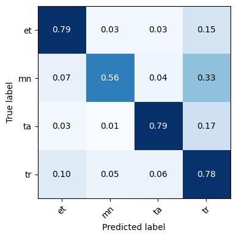

```python
from sklearn.naive_bayes import GaussianNB
from lidbox.util import classification_report


# Fit classifier
clf = GaussianNB()
clf.fit(train_X, train_y)

# Predict scores on test set with classifier and compute metrics
test_pred = clf.predict_log_proba(test_X)
# Clamp -infs to -100
test_pred = np.maximum(-100, test_pred)
report = classification_report(test_y, test_pred, lang2target)
display_classification_report(report)
```

## Conclusions

Compared to the results from our previous examples, we were unable to get better results by training an RNN based model with the angular proximity loss function. However, the PCA scatter plots suggest that language vectors of the same class are much closer to each other compared to what we extracted from the x-vector model.

In any case, we might need much larger datasets before we can reliably compare the x-vector model and the LSTM model we used here.